# Chapter 14

jim108@gmx.net

6/22/2020

```r
library(rethinking)
library(ape)
library(MASS)
library(ellipse)
```

## 14E1.

Given:

$y_i \sim Normal(\mu_i, \sigma)$

$\mu_i = \alpha_{GROUP[i]} + \beta x_i$

$\alpha_{GROUP} \sim Normal(\alpha, sigma_{\alpha})$

$\alpha \sim Normal(0, 10)$

$\beta \sim Normal(0, 1)$

$\sigma \sim HalfCauchy(0, 2)$

$\sigma_{\alpha} \sim HalfCauchy(0, 2)$.

Want: Add varying slopes on the predictor $x$.

Sol.:

$y_i \sim Normal(\mu_i, \sigma)$

$\mu_i = \alpha_{GROUP[i]} + \beta x_i$

$\alpha_{GROUP} \sim Normal(\alpha, sigma_{\alpha})$

$\alpha \sim Normal(0, 10)$

$\beta \sim Normal(0, \sigma_{\beta})$

$\sigma \sim HalfCauchy(0, 2)$

$\sigma_{\alpha} \sim HalfCauchy(0, 2)$

$\sigma_{\beta} \sim HalfCauchy(0, 1)$.

## 14E2.

Want: Example of varying intercepts with positively correlated varying slops.

Sol.: An electrition drives around and checks the energy input of different solar panels mounted in different regions from 8 a.m. till 1 p.m.. In the morning the energy will be low, even in regions with more sunlight and more efficient panels, compared to panels checked at noon.

## 14E3.

Want: When is it possible for a varying slopes model to have fewer effective parameters (as estimated by WAIC or DIC) than the corresponding model with fixed (unpooled) slopes? Explain.

Sol.: An unpooled model has always a higher or equaly high number of parameters than pooled model.

## 14M1.

Given: Café robot simulation with $\rho=0$.

Want: How does the posterior distribution of the correlation reflect this change in the underlying simulation?

Sol.:

```r
geN_cafes <- function(rho){
  a <- 3.5            # average morning wait time
  b <- (-1)           # average difference afternoon wait time
  sigma_a <- 1        # std dev in intercepts
  sigma_b <- 0.5      # std dev in slopes
  #rho <- 0       # correlation between intercepts and slopes

  ## R code 14.2
  Mu <- c( a , b )

  ## R code 14.5
  sigmas <- c(sigma_a,sigma_b) # standard deviations
  Rho <- matrix( c(1,rho,rho,1) , nrow=2 ) # correlation matrix

  # now matrix multiply to get covariance matrix
  Sigma <- diag(sigmas) %*% Rho %*% diag(sigmas)

  ## R code 14.6
  N_cafes <- 20

  ## R code 14.7
  set.seed(5) # used to replicate example
  vary_effects <- mvrnorm( N_cafes , Mu , Sigma )

  ## R code 14.8
  a_cafe <- vary_effects[,1]
  b_cafe <- vary_effects[,2]

  ## R code 14.10
  set.seed(22)
  N_visits <- 10
  afternoon <- rep(0:1,N_visits*N_cafes/2)
  cafe_id <- rep( 1:N_cafes , each=N_visits )
  mu <- a_cafe[cafe_id] + b_cafe[cafe_id]*afternoon
  sigma <- 0.5  # std dev within cafes
  wait <- rnorm( N_visits*N_cafes , mu , sigma )
  return(list(d=data.frame( cafe=cafe_id , afternoon=afternoon , wait=wait), N_cafes=N_cafes, vary_effects=vary_effects, Mu=Mu, Sigma=Sigma))
}

cafes.gen.rho0 <- geN_cafes(rho=0)
cafes.gen.rho0.7 <- geN_cafes(rho=-0.7)
```

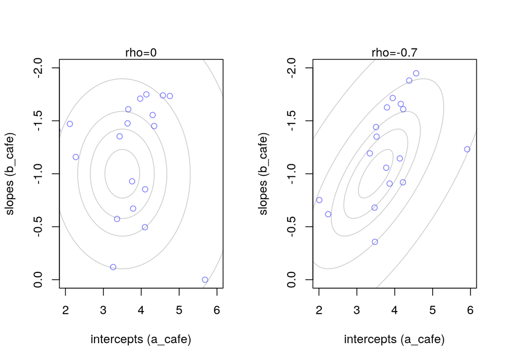

```r
plot_cafes <- function(cafes.gen, title){

  a_cafe <- cafes.gen$vary_effects[,1]
  b_cafe <- cafes.gen$vary_effects[,2]
  plot( a_cafe , b_cafe , col=rangi2 ,
      xlab="intercepts (a_cafe)" , ylab="slopes (b_cafe)", ylim=c(0,-2), xlim=c(2,6))

  # overlay population distribution
  for ( l in c(0.1,0.3,0.5,0.8,0.99) )
      lines(ellipse(cafes.gen$Sigma,centre=cafes.gen$Mu,level=l),col=col.alpha("black",0.2))
  mtext(title)
}

par(mfrow=c(1,2))
plot_cafes(cafes.gen.rho0, "rho=0")
plot_cafes(cafes.gen.rho0.7, "rho=-0.7")
```

```r
l14M1 <- alist(
        wait ~ normal( mu , sigma ),
        mu <- a_cafe[cafe] + b_cafe[cafe]*afternoon,
        c(a_cafe,b_cafe)[cafe] ~ multi_normal( c(a,b) , Rho , sigma_cafe ),
        a ~ normal(5,2),
        b ~ normal(-1,0.5),
        sigma_cafe ~ exponential(1),
        sigma ~ exponential(1),
        Rho ~ lkj_corr(2)
    )
```

```r
set.seed(867530)
m14M1a <- ulam(l14M1, data=cafes.gen.rho0$d , chains=4 , cores=4, log_lik = TRUE )
```

```
## Trying to compile a simple C file
```

```r
set.seed(867530)
m14M1b <- ulam(l14M1, data=cafes.gen.rho0.7$d , chains=4 , cores=4, log_lik = TRUE )
```

```
## recompiling to avoid crashing R session
```

```
## Trying to compile a simple C file
```

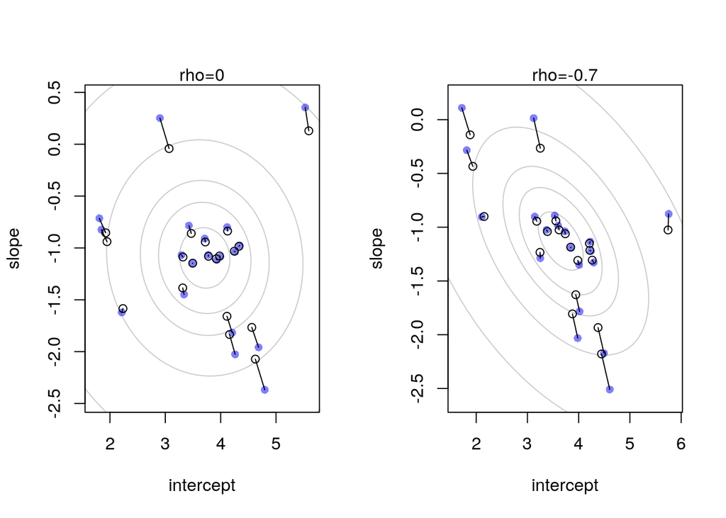

```r
plot_post <- function(model=m14M1a,cafe_data=cafes.gen.rho0, title){
  N_cafes <- cafe_data$N_cafes
  d <- cafe_data$d

  ## R code 14.14
  # compute unpooled estimates directly from data
  a1 <- sapply( 1:N_cafes ,
          function(i) mean(d$wait[d$cafe==i & d$afternoon==0]) )
  b1 <- sapply( 1:N_cafes ,
          function(i) mean(d$wait[d$cafe==i & d$afternoon==1]) ) - a1

  # extract posterior means of partially pooled estimates
  post <- extract.samples(model)
  a2 <- apply( post$a_cafe , 2 , mean )
  b2 <- apply( post$b_cafe , 2 , mean )

  # plot both and connect with lines
  plot( a1 , b1 , xlab="intercept" , ylab="slope" ,
      pch=16 , col=rangi2 , ylim=c( min(b1)-0.1 , max(b1)+0.1 ) ,
      xlim=c( min(a1)-0.1 , max(a1)+0.1 ) )
  points( a2 , b2 , pch=1 )
  for ( i in 1:N_cafes ) lines( c(a1[i],a2[i]) , c(b1[i],b2[i]) )
    ## R code 14.15
  # compute posterior mean bivariate Gaussian
  Mu_est <- c( mean(post$a) , mean(post$b) )
  rho_est <- mean( post$Rho[,1,2] )
  sa_est <- mean( post$sigma_cafe[,1] )
  sb_est <- mean( post$sigma_cafe[,2] )
  cov_ab <- sa_est*sb_est*rho_est
  Sigma_est <- matrix( c(sa_est^2,cov_ab,cov_ab,sb_est^2) , ncol=2 )


  for ( l in c(0.1,0.3,0.5,0.8,0.99) )
      lines(ellipse(Sigma_est,centre=Mu_est,level=l),
          col=col.alpha("black",0.2))
  mtext(title)
}

par(mfrow=c(1,2))
plot_post(model=m14M1a, cafe_data=cafes.gen.rho0, "rho=0")
plot_post(model=m14M1b, cafe_data=cafes.gen.rho0.7, "rho=-0.7")
```

## 14M2.

Given: Café data, model m14M2:

$W_i \sim Normal(\mu_i, \sigma)$

$\mu_i = \alpha_{CAFE[i]} + \beta_{CAFE[i]} A_i$

$\alpha_{CAFE} \sim Normal(\alpha, sigma_{\alpha})$

$\beta_{CAFE} \sim Normal(\beta, \sigma_{\beta})$

$\alpha,\beta \sim Normal(0, 10)$

$\sigma,\sigma_{\alpha},\sigma_{\beta} \sim HalfCauchy(0, 1)$.

Want: Fit model to data, compare to ´m14.1´.

```r
## R code 14.1
a <- 3.5            # average morning wait time
b <- (-1)           # average difference afternoon wait time
sigma_a <- 1        # std dev in intercepts
sigma_b <- 0.5      # std dev in slopes
rho <- (-0.7)       # correlation between intercepts and slopes

## R code 14.2
Mu <- c( a , b )

## R code 14.5
sigmas <- c(sigma_a,sigma_b) # standard deviations
Rho <- matrix( c(1,rho,rho,1) , nrow=2 ) # correlation matrix

# now matrix multiply to get covariance matrix
Sigma <- diag(sigmas) %*% Rho %*% diag(sigmas)

## R code 14.6
N_cafes <- 20

## R code 14.7
library(MASS)
set.seed(5) # used to replicate example
vary_effects <- mvrnorm( N_cafes , Mu , Sigma )

## R code 14.8
a_cafe <- vary_effects[,1]
b_cafe <- vary_effects[,2]

## R code 14.10
set.seed(22)
N_visits <- 10
afternoon <- rep(0:1,N_visits*N_cafes/2)
cafe_id <- rep( 1:N_cafes , each=N_visits )
mu <- a_cafe[cafe_id] + b_cafe[cafe_id]*afternoon
sigma <- 0.5  # std dev within cafes
wait <- rnorm( N_visits*N_cafes , mu , sigma )
d <- data.frame( cafe=cafe_id , afternoon=afternoon , wait=wait )
```

```r
set.seed(867530)
m14.1 <- ulam(
    alist(
        wait ~ normal( mu , sigma ),
        mu <- a_cafe[cafe] + b_cafe[cafe]*afternoon,
        c(a_cafe,b_cafe)[cafe] ~ multi_normal( c(a,b) , Rho , sigma_cafe ),
        a ~ normal(5,2),
        b ~ normal(-1,0.5),
        sigma_cafe ~ exponential(1),
        sigma ~ exponential(1),
        Rho ~ lkj_corr(2)
    ) , data=d , chains=4 , cores=4, iter=1e4, control = list(adapt_delta=0.99), log_lik = TRUE  )
```

```
## recompiling to avoid crashing R session
```

```
## Trying to compile a simple C file
```

```r
p14.1 <- precis(m14.1, depth=3)
p14.1[c("Rho[1,1]"),]
```

```
##          mean sd 5.5% 94.5% n_eff Rhat4
## Rho[1,1]    1  0    1     1   NaN   NaN
```

```r
p14.1[c("Rho[2,2]"),]
```

```
##          mean           sd 5.5% 94.5%    n_eff  Rhat4
## Rho[2,2]    1 7.141511e-17    1     1 114.7686 0.9998
```

```r
set.seed(867530)
m14M2 <- ulam(
    alist(
        wait ~ normal( mu , sigma ),
        mu <- a_cafe[cafe] + b_cafe[cafe]*afternoon,
        a_cafe[cafe] ~ normal(a, sigma_a),
        b_cafe[cafe] ~ normal(b, sigma_b),
        c(a,b) ~ normal(0,10),
        c(sigma, sigma_a, sigma_b) ~ half_cauchy(0,1)
    ) , data=d , chains=4 , cores=4, log_lik = TRUE  )
```

```
## Trying to compile a simple C file
```

```r
compare(m14.1, m14M2)
```

```
##           WAIC       SE    dWAIC      dSE    pWAIC    weight
## m14.1 305.7232 17.73893 0.000000       NA 33.09280 0.5853248
## m14M2 306.4126 18.03432 0.689343 2.184778 32.63456 0.4146752
```

## 14M3.

Given: `UCBadmit` data.

Want: Re-estimate with varying slopes and non-centered parameters. Compare `n_eff`.

Sol.:

```r
data(UCBadmit)
d <- UCBadmit
head(d)
```

```
##   dept applicant.gender admit reject applications
## 1    A             male   512    313          825
## 2    A           female    89     19          108
## 3    B             male   353    207          560
## 4    B           female    17      8           25
## 5    C             male   120    205          325
## 6    C           female   202    391          593
```

```r
dat_list <- list(
    admit = d$admit,
    applications = d$applications,
    gid = ifelse( d$applicant.gender=="male" , 1 , 2 ),
    dept_id = rep(1:6,each=2)
)
```

```r
set.seed(1)
m11.7 <- ulam(
    alist(
        admit ~ dbinom( applications , p ) ,
        logit(p) <- a[gid] ,
        a[gid] ~ dnorm( 0 , 1.5 )
    ) , data=dat_list , chains=4, cores=4, log_lik=TRUE )
```

```
## Trying to compile a simple C file
```

```r
set.seed(1)
m14M3a <- ulam(
    alist(
        admit ~ dbinom( applications , p ) ,
        logit(p) <- a[gid] + delta[dept_id,gid] ,

        # adaptive priors
        vector[4]:delta[dept_id] ~ multi_normal(0,Rho_delta,sigma_delta),

        # fixed priors
        a[gid] ~ dnorm( 0 , 1.5 ) ,
        sigma_delta ~ dexp(1),
        Rho_delta ~ dlkjcorr(4)
    ) , data=dat_list , chains=4 , cores=4, log_lik = TRUE)
```

```
## Trying to compile a simple C file
```

```r
set.seed(1)
m14M3b <- ulam(
    alist(
        admit ~ dbinom( applications , p ) ,
        logit(p) <- a[gid] + delta[dept_id,gid] ,

        # adaptive priors
        transpars> matrix[dept_id,4]:delta <-compose_noncentered( sigma_delta, L_Rho_delta, z_delta),
        matrix[4,dept_id]:z_delta ~ normal(0, 1),

        # fixed priors
        a[gid] ~ dnorm( 0 , 1.5 ) ,
        vector[4]:sigma_delta ~ dexp(1),
        cholesky_factor_corr[4]:L_Rho_delta ~ lkj_corr_cholesky(2),

        gq> matrix[4,4]:Rho_delta <<- Chol_to_Corr(L_Rho_delta)
    ) , data=dat_list , chains=4 , cores=4, log_lik = TRUE)
```

```
## Trying to compile a simple C file
```

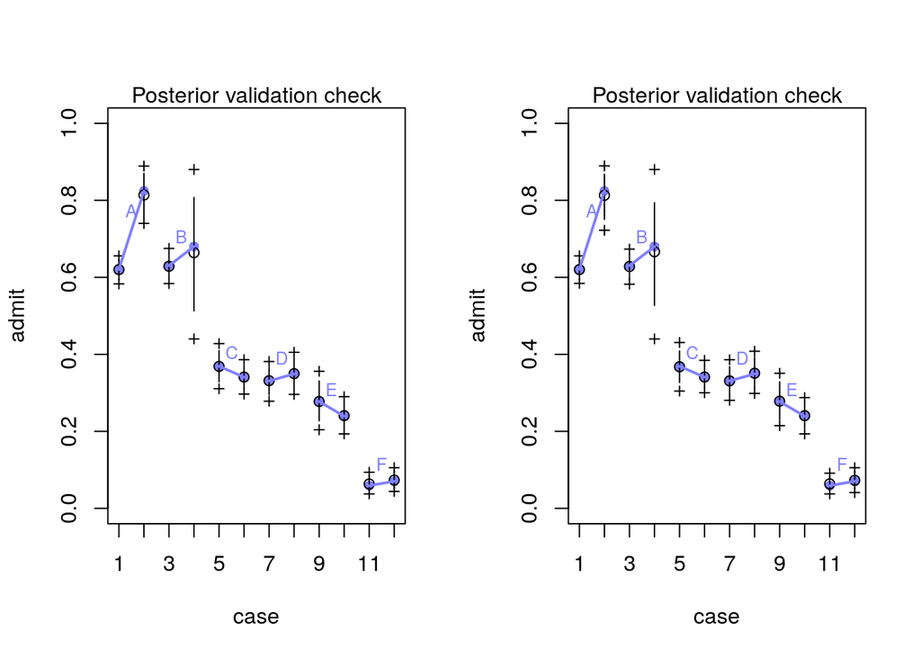

```r
plot_admissions <- function(model, title){
  ## R code 11.30
  post <- extract.samples(model)
  diff_a <- post$a[,1] - post$a[,2]
  diff_p <- inv_logit(post$a[,1]) - inv_logit(post$a[,2])
  precis( list( diff_a=diff_a , diff_p=diff_p ) )

  ## R code 11.31
  postcheck( model )
  # draw lines connecting points from same dept
  for ( i in 1:6 ) {
      x <- 1 + 2*(i-1)
      y1 <- d$admit[x]/d$applications[x]
      y2 <- d$admit[x+1]/d$applications[x+1]
      lines( c(x,x+1) , c(y1,y2) , col=rangi2 , lwd=2 )
      text( x+0.5 , (y1+y2)/2 + 0.05 , d$dept[x] , cex=0.8 , col=rangi2 )
  }
}

par(mfrow=c(1,2))
plot_admissions(m14M3a)
plot_admissions(m14M3b)
```

```r
p14M3a <- precis(m14M3a, depth = 3)
summary(p14M3a$n_eff)
```

```
##    Min. 1st Qu.  Median    Mean 3rd Qu.    Max.    NA's
##   122.6   591.7  1327.7  1166.8  1739.8  2010.4       1
```

```r
p14M3b <- precis(m14M3b, depth = 3)
summary(p14M3b$n_eff)
```

```
##    Min. 1st Qu.  Median    Mean 3rd Qu.    Max.    NA's
##   448.1   790.3  1478.6  1620.2  2480.5  3162.1       8
```

- m14M3a had 20 divergent transitions, m14M3b had non.
- The minimum number of effective samples for all variables was 3 times higher at the non-centered model.
- The non-centered model sampels about 5 times faster than the centered model.
- The infered coefficients are the same, therefore the non-centered model is better.

## 14M4.

Given: Oceanic tools data.

Want: WAIC-compare model with distance matrix to model without distance matrix.

Sol.:

```r
## R code 14.39
data(Kline2) # load the ordinary data, now with coordinates
d <- Kline2
d$society <- 1:10 # index observations
data(islandsDistMatrix)
head(d)
```

```
##      culture population contact total_tools mean_TU   lat   lon  lon2   logpop
## 1   Malekula       1100     low          13     3.2 -16.3 167.5 -12.5 7.003065
## 2    Tikopia       1500     low          22     4.7 -12.3 168.8 -11.2 7.313220
## 3 Santa Cruz       3600     low          24     4.0 -10.7 166.0 -14.0 8.188689
## 4        Yap       4791    high          43     5.0   9.5 138.1 -41.9 8.474494
## 5   Lau Fiji       7400    high          33     5.0 -17.7 178.1  -1.9 8.909235
## 6  Trobriand       8000    high          19     4.0  -8.7 150.9 -29.1 8.987197
##   society
## 1       1
## 2       2
## 3       3
## 4       4
## 5       5
## 6       6
```

```r
dat_list <- list(
    T = d$total_tools,
    P = d$population,
    society = d$society,
    Dmat=islandsDistMatrix,
    cid = d$contact_id)
```

```r
m14M4a <- ulam(
    alist(
        T ~ dpois(lambda),
        lambda <- (a*P^b/g)*exp(k[society]),
        vector[10]:k ~ multi_normal( 0 , SIGMA ),
        matrix[10,10]:SIGMA <- cov_GPL2( Dmat , etasq , rhosq , 0.01 ),
        c(a,b,g) ~ dexp( 1 ),
        etasq ~ dexp( 2 ),
        rhosq ~ dexp( 0.5 )
    ), data=dat_list , chains=4 , cores=4 , log_lik=TRUE)
```

```
## Trying to compile a simple C file
```

```r
dat <- list(
    T = d$total_tools ,
    P = scale(log(d$population)) ,
    cid = ifelse( d$contact=="high" , 2 , 1 )
)
```

```r
# interaction model
m14M4b <- ulam(
    alist(
        T ~ dpois( lambda ),
        log(lambda) <- a[cid] + b[cid]*P,
        a[cid] ~ dnorm( 3 , 0.5 ),
        b[cid] ~ dnorm( 0 , 0.2 )
    ), data=dat , chains=4 , cores = 4, log_lik=TRUE )
```

```
## Trying to compile a simple C file
```

```r
compare(m14M4a, m14M4b)
```

```
##            WAIC        SE    dWAIC      dSE    pWAIC       weight
## m14M4a 67.82424  2.388192  0.00000       NA 4.149296 0.9996074618
## m14M4b 83.50921 12.288124 15.68497 12.08905 6.133514 0.0003925382
```

## 14M5.

Given: Primates data.

Want: Model with group size as the outcome and brain size as a predictor. What is the effect of brain size on group size? How does phylogeny influence the estimate?

Sol.:

```r
data(Primates301)
data(Primates301_nex)
d <- Primates301
head(d)
```

```
##                          name          genus      species subspecies spp_id
## 1 Allenopithecus_nigroviridis Allenopithecus nigroviridis       <NA>      1
## 2         Allocebus_trichotis      Allocebus    trichotis       <NA>      2
## 3           Alouatta_belzebul       Alouatta     belzebul       <NA>      3
## 4             Alouatta_caraya       Alouatta       caraya       <NA>      4
## 5            Alouatta_guariba       Alouatta      guariba       <NA>      5
## 6           Alouatta_palliata       Alouatta     palliata       <NA>      6
##   genus_id social_learning research_effort brain    body group_size gestation
## 1        1               0               6 58.02 4655.00       40.0        NA
## 2        2               0               6    NA   78.09        1.0        NA
## 3        3               0              15 52.84 6395.00        7.4        NA
## 4        3               0              45 52.63 5383.00        8.9    185.92
## 5        3               0              37 51.70 5175.00        7.4        NA
## 6        3               3              79 49.88 6250.00       13.1    185.42
##   weaning longevity sex_maturity maternal_investment
## 1  106.15     276.0           NA                  NA
## 2      NA        NA           NA                  NA
## 3      NA        NA           NA                  NA
## 4  323.16     243.6      1276.72              509.08
## 5      NA        NA           NA                  NA
## 6  495.60     300.0      1578.42              681.02
```

```r
d$name <- as.character(d$name)
dstan <- d[ complete.cases( d$group_size , d$body , d$brain ) , ]
spp_obs <- dstan$name

dat_list <- list(
    N_spp = nrow(dstan),
    M = standardize(log(dstan$body)),
    B = standardize(log(dstan$brain)),
    G = standardize(log(dstan$group_size)),
    Imat = diag(nrow(dstan)) )
```

```r
m14M5a <- ulam(
    alist(
        G ~ multi_normal( mu , SIGMA ),
        mu <- a + bM*M + bB*B,
        matrix[N_spp,N_spp]: SIGMA <- Imat * sigma_sq,
        a ~ normal( 0 , 1 ),
        c(bM,bB) ~ normal( 0 , 0.5 ),
        sigma_sq ~ exponential( 1 )
    ), data=dat_list , chains=4 , cores=4 )
```

```
## Trying to compile a simple C file
```

```r
tree_trimmed <- keep.tip( Primates301_nex, spp_obs )
Rbm <- corBrownian( phy=tree_trimmed )
V <- vcv(Rbm)
Dmat <- cophenetic( tree_trimmed )
dat_list$V <- V[ spp_obs , spp_obs ]
dat_list$R <- dat_list$V / max(V)
dat_list$Dmat <- Dmat[ spp_obs , spp_obs ] / max(Dmat)
```

```r
set.seed(1)
m14M5b <- ulam(
    alist(
        G ~ multi_normal( mu , SIGMA ),
        mu <- a + bM*M + bB*B,
        matrix[N_spp,N_spp]: SIGMA <- cov_GPL1( Dmat , etasq , rhosq , 0.01 ),
        a ~ normal(0,1),
        c(bM,bB) ~ normal(0,0.5),
        etasq ~ half_normal(1,0.25),
        rhosq ~ half_normal(3,0.25)
    ), data=dat_list , chains=4 , cores=4 )
```

```
## Trying to compile a simple C file
```

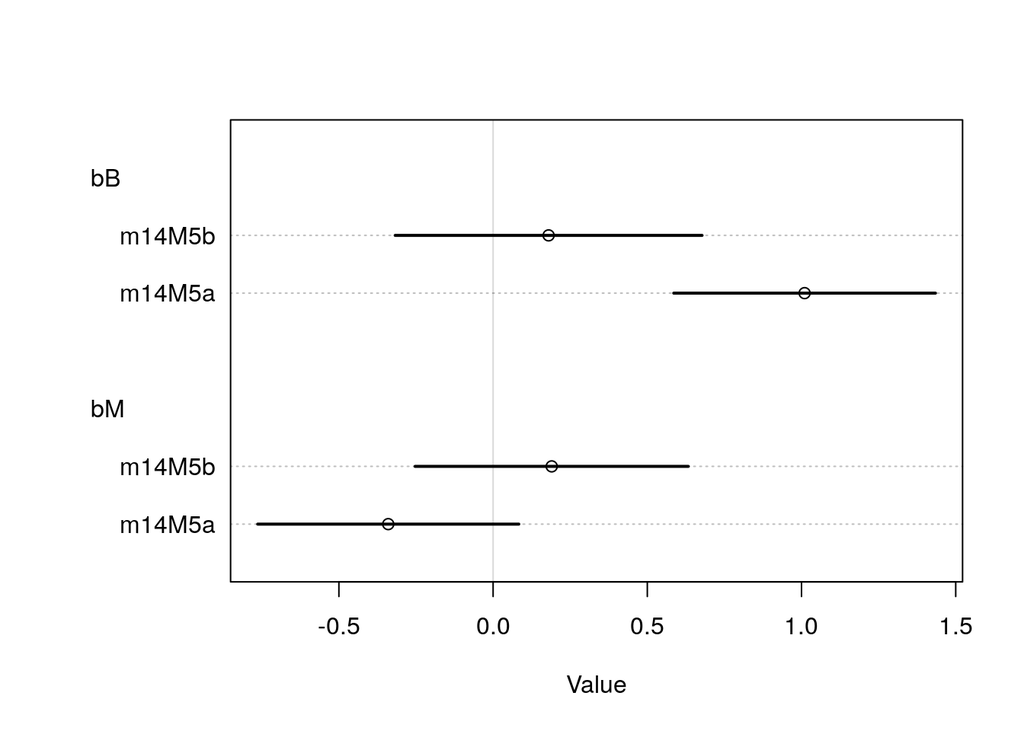

```r
plot( coeftab(m14M5a,m14M5b) , pars=c("bB","bM") )
```

- According to the coefficient plot, brain size is strongly positive correlated with group size if the phylogenic distances are omitted. (m14M5a.bB)
- On the other hand brain size is weakly positive correlated with group size if the phylogenic distances are considered. (m14M5b.bB)

## 14H1.

Given: Bangladesh contraception data.

Want: Predict `use.contraception` with varying intercepts by `district_id` and varying slopes of `urban` by `district_id`. Plot mean (or meadian) varying effect estimates for intercepts and slopes, by district. Plot predicted proportion of woman using contraception. Interpret.

```r
data("bangladesh")
d <- bangladesh

summary(d)
```

```
##      woman           district     use.contraception living.children
##  Min.   :   1.0   Min.   : 1.00   Min.   :0.0000    Min.   :1.000
##  1st Qu.: 484.2   1st Qu.:14.00   1st Qu.:0.0000    1st Qu.:1.000
##  Median : 967.5   Median :29.00   Median :0.0000    Median :3.000
##  Mean   : 967.5   Mean   :29.35   Mean   :0.3925    Mean   :2.652
##  3rd Qu.:1450.8   3rd Qu.:45.00   3rd Qu.:1.0000    3rd Qu.:4.000
##  Max.   :1934.0   Max.   :61.00   Max.   :1.0000    Max.   :4.000
##   age.centered            urban
##  Min.   :-13.560000   Min.   :0.0000
##  1st Qu.: -7.559900   1st Qu.:0.0000
##  Median : -1.559900   Median :0.0000
##  Mean   :  0.002198   Mean   :0.2906
##  3rd Qu.:  6.440000   3rd Qu.:1.0000
##  Max.   : 19.440000   Max.   :1.0000
```

```r
dat <- list(
    C = d$use.contraception,
    did = as.integer(as.factor(d$district)),
    uid = as.integer(as.factor(d$urban)),
    urban = d$urban
)
summary(dat)
```

```
##       Length Class  Mode
## C     1934   -none- numeric
## did   1934   -none- numeric
## uid   1934   -none- numeric
## urban 1934   -none- numeric
```

```r
set.seed(867530)
m14H1 <- ulam(
    alist(
        C ~ normal( mu , sigma ),
        mu <- a_district[did] + b_district[did]*urban,
        c(a_district,b_district)[did] ~ multi_normal( c(a,b) , Rho , sigma_district ),
        a ~ normal(0,1),
        b ~ normal(0,1),
        sigma_district ~ exponential(1),
        sigma ~ exponential(1),
        Rho ~ lkj_corr(2)
    ) , data=dat , chains=4 , cores=4 )
```

```
## Trying to compile a simple C file
```

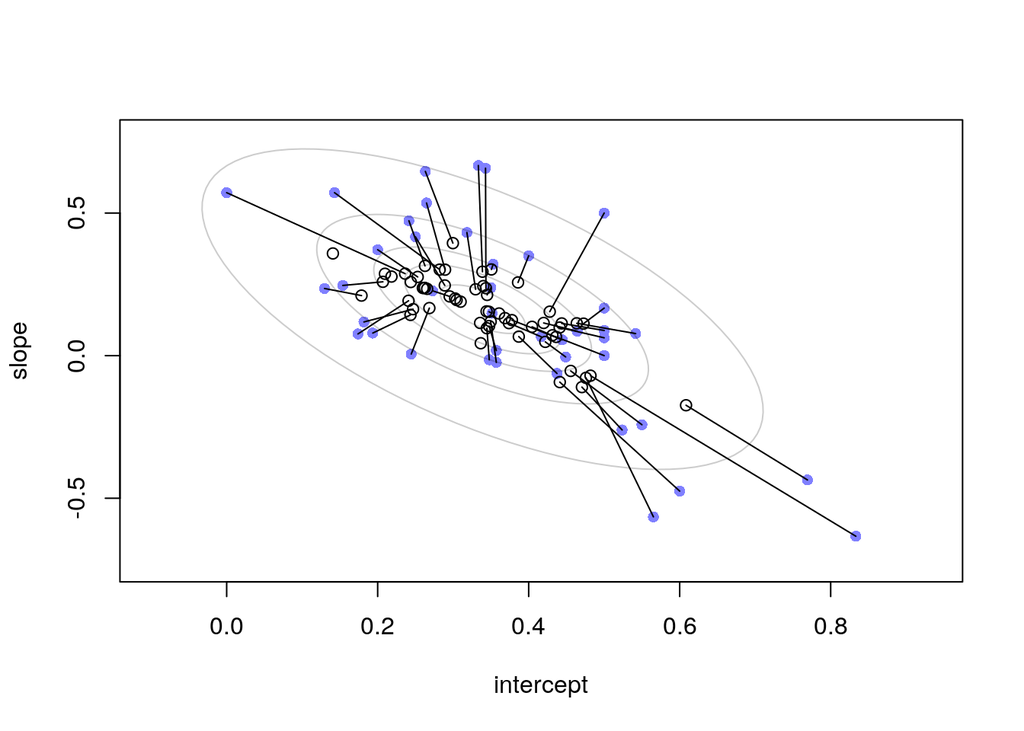

```r
N_districts <- length(unique(dat$did))

a1 <- sapply( 1:N_districts ,
        function(i) mean(dat$C[dat$did==i & dat$urban==0]) )
b1 <- sapply( 1:N_districts ,
        function(i) mean(dat$C[dat$did==i & dat$urban==1]) ) - a1

post <- extract.samples(m14H1)
a2 <- apply( post$a_district , 2 , mean )
b2 <- apply( post$b_district , 2 , mean )

# plot both and connect with lines
plot( a1 , b1 , xlab="intercept" , ylab="slope" ,
    pch=16 , col=rangi2 , ylim=c( min(b1,na.rm = TRUE)-0.1 , max(b1, na.rm = TRUE)+0.1 ) ,
    xlim=c( min(a1, na.rm=TRUE)-0.1 , max(a1, na.rm=TRUE)+0.1 ) )
points( a2 , b2 , pch=1 )
for ( i in 1:N_districts ) lines( c(a1[i],a2[i]) , c(b1[i],b2[i]) )

# compute posterior mean bivariate Gaussian
Mu_est <- c( mean(post$a) , mean(post$b) )
rho_est <- mean( post$Rho[,1,2] )
sa_est <- mean( post$sigma_district[,1] )
sb_est <- mean( post$sigma_district[,2] )
cov_ab <- sa_est*sb_est*rho_est
Sigma_est <- matrix( c(sa_est^2,cov_ab,cov_ab,sb_est^2) , ncol=2 )

# draw contours
for ( l in c(0.1,0.3,0.5,0.8,0.99) )
    lines(ellipse(Sigma_est,centre=Mu_est,level=l),
        col=col.alpha("black",0.2))
```

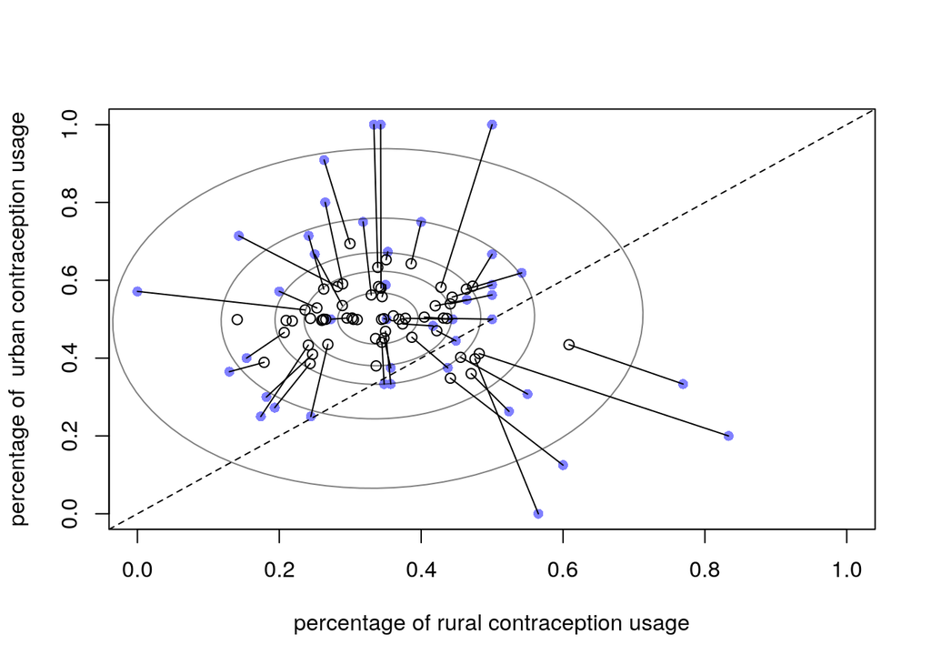

```r
# convert varying effects to waiting times
C_rural_1 <- (a1)
C_urban_1 <- (a1 + b1)
C_rural_2 <- (a2)
C_urban_2 <- (a2 + b2)

# plot both and connect with lines
plot( C_rural_1 , C_urban_1 , xlab="percentage of rural contraception usage" ,
    ylab="percentage of  urban contraception usage" , pch=16 , col=rangi2 ,
    ylim=c(0,1),xlim=c(0,1 ))
points( C_rural_2 , C_urban_2 , pch=1 )
for ( i in 1:N_districts )
    lines( c(C_rural_1[i],C_rural_2[i]) ,
    c(C_urban_1[i],C_urban_2[i]) )
abline( a=0 , b=1 , lty=2 )

# now shrinkage distribution by simulation
v <- mvrnorm( 1e4 , Mu_est , Sigma_est )
v[,2] <- v[,1] + v[,2]
Sigma_est2 <- cov(v)
Mu_est2 <- Mu_est
Mu_est2[2] <- Mu_est[1]+Mu_est[2]

# draw contours
for ( l in c(0.1,0.3,0.5,0.8,0.99) )
    lines(ellipse(Sigma_est2,centre=Mu_est2,level=l),
        col=col.alpha("black",0.5))
```

```r
# center
Mu_est2
```

```
## [1] 0.3389737 0.5018857
```

- Predition outside of the center/mean are heavily shrunk towards the mean. Using one mean and cov. for intercepts and slops is very restricting.
- The predicted center is around 0.3, 0.5, meaning urban districts are predicted to use about 20 % more contraception then rural districts, as expected.

## 14H2.

Given: Oxford Boys Club data.

Want: Fit a model with varying intercepts and slopes, predicting height, using age, clustered by `Subject`. Present and interpret the parameter estimates. Which varying effect contributes more variation to the heights, the intercept or the slope?

Sol.:

```r
data("Oxboys")
d <- Oxboys
summary(d)
```

```
##     Subject          age               height         Occasion
##  Min.   : 1.0   Min.   :-1.00000   Min.   :126.2   Min.   :1
##  1st Qu.: 7.0   1st Qu.:-0.46300   1st Qu.:143.8   1st Qu.:3
##  Median :13.5   Median :-0.00270   Median :149.5   Median :5
##  Mean   :13.5   Mean   : 0.02263   Mean   :149.5   Mean   :5
##  3rd Qu.:20.0   3rd Qu.: 0.55620   3rd Qu.:155.5   3rd Qu.:7
##  Max.   :26.0   Max.   : 1.00550   Max.   :174.8   Max.   :9
```

```r
dat <- list(
    H = d$height,
    A = d$age,
    sid = as.integer(d$Subject)
)
summary(dat)
```

```
##     Length Class  Mode
## H   234    -none- numeric
## A   234    -none- numeric
## sid 234    -none- numeric
```

```r
#Sermon on priors
#Height of a boy 150 cm +-30
#Strong positive correlation between age and height, thus b=30 +- 10, Rho ~ lkj_corr(1)
```

```r
set.seed(867530)
m14H2 <- ulam(
    alist(
        H ~ normal( mu , sigma ),
        mu <- a_subject[sid] + b_subject[sid]*A,
        c(a_subject,b_subject)[sid] ~ multi_normal( c(a,b) , Rho , sigma_subject ),
        a ~ normal(150,5),
        b ~ normal(30,5),
        c(sigma_subject,sigma) ~ exponential(1),
        Rho ~ lkj_corr(1)
    ) , data=dat , chains=4 , cores=4 )
```

```
## Trying to compile a simple C file
```

```r
pr <- precis(m14H2, depth = 3)
pr[is.na(pr$Rhat4),]
```

```
##          mean sd 5.5% 94.5% n_eff Rhat4
## Rho[1,1]    1  0    1     1   NaN   NaN
```

```r
pr[c("a","b"),]
```

```
##         mean        sd       5.5%      94.5%    n_eff    Rhat4
## a 149.612878 1.3568229 147.432898 151.772183 2881.392 1.001906
## b   6.629878 0.3245358   6.119811   7.157649 2529.559 1.002269
```

- The standard deviation of the intercept is higher than the standard deviation on the slope, thus the intercept contributes more to the vatiation.

## 14H3.

Given: Oxford Boys Club data.

Want: Explain correlation values between the varying intercepts and slops. How would this estimated correlation influence your predictions about a new sample of boys.

Sol.:

```r
pr[c("Rho[1,2]"),]
```

```
##               mean        sd      5.5%     94.5%    n_eff    Rhat4
## Rho[1,2] 0.5475412 0.1274856 0.3257254 0.7297986 2984.253 1.000049
```

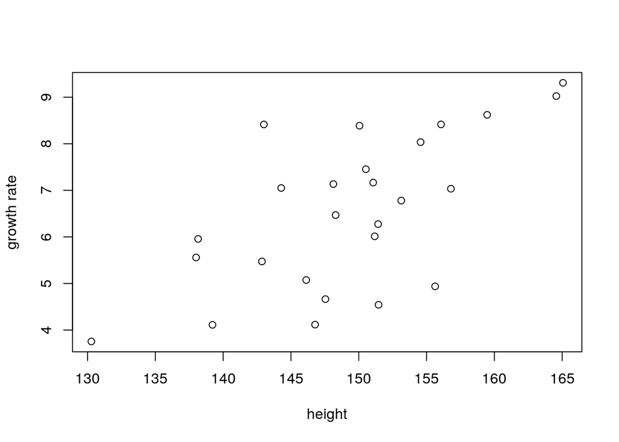

```r
post <- extract.samples(m14H2)
a2 <- apply( post$a_subject , 2 , mean )
b2 <- apply( post$b_subject , 2 , mean )
plot(a2, b2, xlab="height", ylab="growth rate")
```

- Slope and intercept are positively correlated, thus boyes who are relatively tall are predicted to have a higher the growth rate.

## 14H4.

Given: 14H3.

Want: Simulate new sample of 10 boys. Plot the predicted trends of height on age, one trend for each simulated boy you produce.

Sol.:

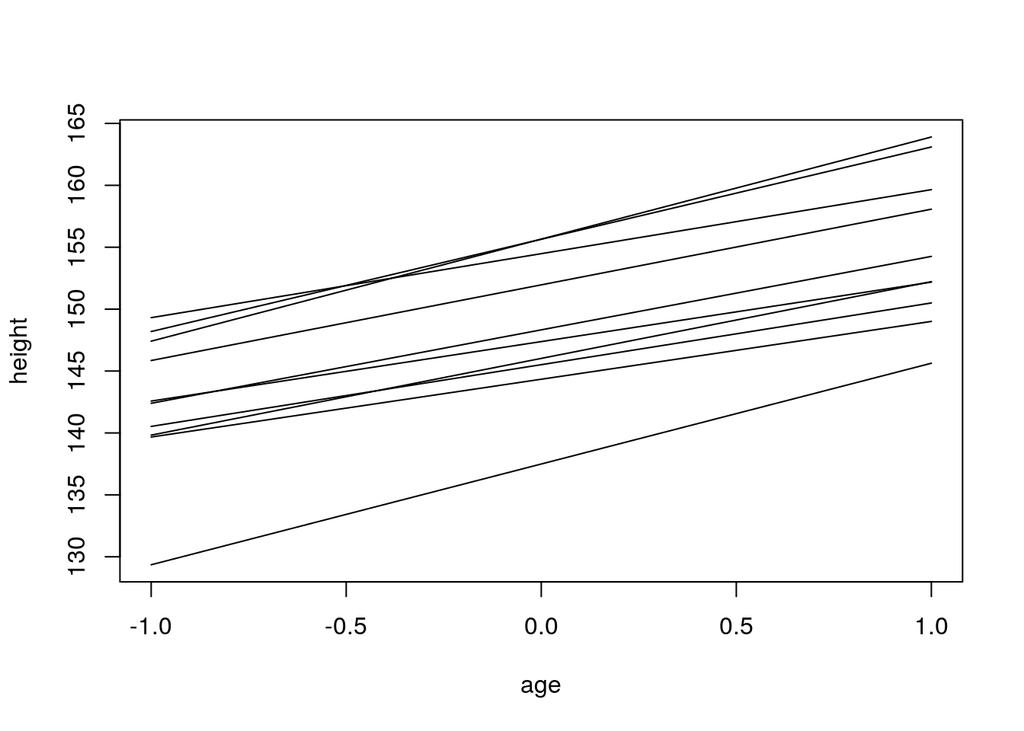

```r
# compute posterior mean bivariate Gaussian
Mu_est <- c( mean(post$a) , mean(post$b) )
rho_est <- mean( post$Rho[,1,2] )
sa_est <- mean( post$sigma_subject[,1] )
sb_est <- mean( post$sigma_subject[,2] )
cov_ab <- sa_est*sb_est*rho_est
Sigma_est <- matrix( c(sa_est^2,cov_ab,cov_ab,sb_est^2) , ncol=2 )

set.seed(1)
N <- 10
a_b.sim <- mvrnorm( N , Mu_est , Sigma_est )
a.sim <- a_b.sim[,1]
b.sim <- a_b.sim[,2]
A_seq <- seq( from=-1 , to=1, length.out=30 )
H.sim <- a.sim + b.sim%o%A_seq

plot(NULL, xlab="age", ylab="height" , xlim=c(-1,1), ylim=c(min(H.sim),max(H.sim)), type="n" )
for (i in 1:10){
  lines(A_seq, H.sim[i,])
}
```